# BRIDGES Engine: knowledge base

NSF Regional Innovation Engines, Cohort 2. Technology profile v1. Draft, in progress

**NSF BRIDGES Engine in Alabama and Tennessee**, led by HudsonAlpha Institute for Biotechnology. NSF award 2532496, start August 2026. Search window for papers and patents: from August 2021 (five years before the award) onward.

## At a glance

| Measure | Value |
| --- | --- |
| People named by NSF or the Engine’s site | 14 |
| of them active researchers (>= 5 works since window start) | 6 |
| Team members who are inventors (2021-2025 grants, in the region) | 1 |
| Partners (site list + team members’ organisations) | 11 |
| Knowledge-producer partners (universities, labs, institutes) | 6 |
| Partner papers in the Engine’s topics | 1248 |
| of them with an in-region partner | 663 |
| Regional patents in the technology profile (2021-2025 grants) | 522 |
| Location quotient of the technology profile (patents) | 1.52 |
| Share of regional technology patents owned by partners | 3.6% |

## Economic base

| NAICS | Industry | Employment in region | Establishments | Share of US employment | Employment LQ |
| --- | --- | --- | --- | --- | --- |
| 3221 | Pulp, paper, and paperboard mills | 10,021 | 30 | 11.0% | 3.22 |
| 3261 | Plastics product manufacturing | 32,005 | 354 | 4.7% | 1.38 |
| 3363 | Motor vehicle parts manufacturing | 75,504 | 342 | 12.9% | 3.75 |
| 3273 | Cement and concrete product manufacturing | 9,053 | 406 | 4.8% | 1.39 |

Industries related to the Engine’s technology (chosen from the NSF abstract, see `data/manual/engine_naics.csv`). County Business Patterns 2023; LQ = the industry’s share of regional employment relative to its share of US employment (1 = US average). Region: whole state(s).

## Technology profile

Version 1. The profile has 4 statements. Item 1 comes from the grant title, the rest from the technical part of the NSF abstract. Each statement is mapped to one OpenAlex topic and to CPC codes.

| # | Source | Statement | OpenAlex topic | Subfield | CPC |
| --- | --- | --- | --- | --- | --- |
| 1 | title | Biobased manufacturing of materials and products from locally grown biomass | Biofuel production and bioconversion | Biomedical Engineering | C08H; C08L97 |
| 2 | abstract | Perennial grasses miscanthus and switchgrass as feedstock for advanced manufacturing | Bioenergy crop production and management | Agronomy and Crop Science | A01H; D21C |
| 3 | abstract | Biobased materials for automotive parts, construction materials and packaging | Natural Fiber Reinforced Composites | Polymers and Plastics | C04B18; B65D65; C08L |
| 4 | abstract | Digital twins and AI decision support for crop design and manufacturing efficiency | Smart Agriculture and AI | Plant Science | G06Q50; G05B17 |

## People

| Role | People |
| --- | --- |
| organizer | 8 |
| researcher | 6 |

[output not shown]

Publication counts are shown only where the OpenAlex author matches both the name and the person’s current organisation. The OpenAlex link is given only for these reliable matches, and not for profiles flagged as possibly merging several namesakes. *Site* links to the page of the Engine’s website where the person is named. Click a number of works to see the list on the Publications page. *Patents*: US grants 2021-2025 with the person among the inventors (same last and first name, address in the Engine’s states); click the number for the list on the Patents page. In brackets: works in the Engine’s topics, patents with a CPC code in the Engine’s technology profile.

## Researchers at partner organisations

| # | Researcher | Partner | Works in the Engine’s topics | Citations | Years | Most cited of these works |
| --- | --- | --- | --- | --- | --- | --- |
| 1 | [Arthur J. Ragauskas](https://openalex.org/A5038999513) | University of Tennessee | 137 | 5379 | 2021-2026 | [Lignin-enzyme interaction: A roadblock for efficient enzy…](https://openalex.org/W3209818289) |
| 2 | [Xianzhi Meng](https://openalex.org/A5078666763) | University of Tennessee | 76 | 3952 | 2021-2026 | [Lignin-enzyme interaction: A roadblock for efficient enzy…](https://openalex.org/W3209818289) |
| 3 | [Hao Gan](https://openalex.org/A5048733352) | University of Tennessee | 18 | 324 | 2022-2026 | [Pose estimation-based lameness recognition in broiler usi…](https://openalex.org/W4225854610) |
| 4 | [Yang Zhao](https://openalex.org/A5026250307) | University of Tennessee | 17 | 307 | 2022-2025 | [Pose estimation-based lameness recognition in broiler usi…](https://openalex.org/W4225854610) |
| 5 | [Tanzeel U. Rehman](https://openalex.org/A5052104716) | Auburn University | 17 | 255 | 2022-2026 | [Trends and Prospect of Machine Vision Technology for Stre…](https://openalex.org/W4313247118) |
| 6 | [Amin Nasiri](https://openalex.org/A5060833840) | University of Tennessee | 16 | 496 | 2021-2026 | [Pose estimation-based lameness recognition in broiler usi…](https://openalex.org/W4225854610) |
| 7 | [Chetan Badgujar](https://openalex.org/A5039433636) | University of Tennessee | 15 | 670 | 2023-2026 | [Agricultural object detection with You Only Look Once (YO…](https://openalex.org/W4399235601) |
| 8 | [Uday Kumar Vaidya](https://openalex.org/A5054553280) | University of Tennessee | 15 | 243 | 2021-2026 | [Impact of biomass ash content on biocomposite properties](https://openalex.org/W4306894174) |
| 9 | [Jeremy C. Smith](https://openalex.org/A5018366869) | University of Tennessee | 14 | 162 | 2022-2026 | [Chemical and Morphological Structure of Transgenic Switch…](https://openalex.org/W4284669632) |
| 10 | [Sanjita Wasti](https://openalex.org/A5061734271) | University of Tennessee | 11 | 442 | 2021-2025 | [Recycling of natural fiber composites: Challenges and opp…](https://openalex.org/W3210008856) |
| 11 | [David P. Harper](https://openalex.org/A5069780226) | University of Tennessee | 11 | 242 | 2022-2026 | [Novel flexible, strong, thermal-stable, and high-barrier …](https://openalex.org/W4213231917) |
| 12 | [Yunxuan Wang](https://openalex.org/A5004260512) | University of Tennessee | 11 | 200 | 2022-2026 | [Applications of biomass-derived solvents in biomass pretr…](https://openalex.org/W4308581290) |
| 13 | [Sushil Adhikari](https://openalex.org/A5024939771) | Auburn University | 10 | 113 | 2021-2026 | [Upcycling Coffee Waste: Key Industrial Activities for Adv…](https://openalex.org/W4405320916) |
| 14 | [Kankshita Swaminathan](https://openalex.org/A5064584191) (team) | HudsonAlpha Institute for Biotechnology | 10 | 81 | 2022-2026 | [Cell‐type‐specific transcriptomics uncovers spatial regul…](https://openalex.org/W4392162446) |
| 15 | [Mitra Mazarei](https://openalex.org/A5089068083) | University of Tennessee | 10 | 71 | 2021-2026 | [Economic and Sustainability Impacts of Yield and Composit…](https://openalex.org/W4391090384) |

The grant names mostly managers; the technology is often developed at the partner universities and labs. These are the authors with the most works in the Engine’s OpenAlex topics written at a knowledge-producer partner in the Engine’s states, since the window start (at least 3 works; top 15). The list depends on the technology profile version. OpenAlex sometimes merges namesakes into one author: check the profile before relying on a name.

## Partners

| Organisation class | Partners |
| --- | --- |
| university | 5 |
| company | 4 |
| investor | 1 |
| research_institute | 1 |

Partner list on the site: *Only the 5 coalition leads are named; the page reports 42 industry, 18 academic, 10 commercialization partners and 15 stakeholder groups as logo images without names*.

| Partner | Class | State | OpenAlex works since window (all topics) |
| --- | --- | --- | --- |
| Georgia Institute of Technology | university | Georgia | 55611 |
| North Carolina State University | university | North Carolina | 52126 |
| University of Tennessee | university | Tennessee | 38850 |
| Auburn University | university | Alabama | 23086 |
| HudsonAlpha Institute for Biotechnology | research_institute | Alabama | 1777 |
| Alabama A&M University | university |  | NA |

## Science base: partner papers in the Engine’s topics

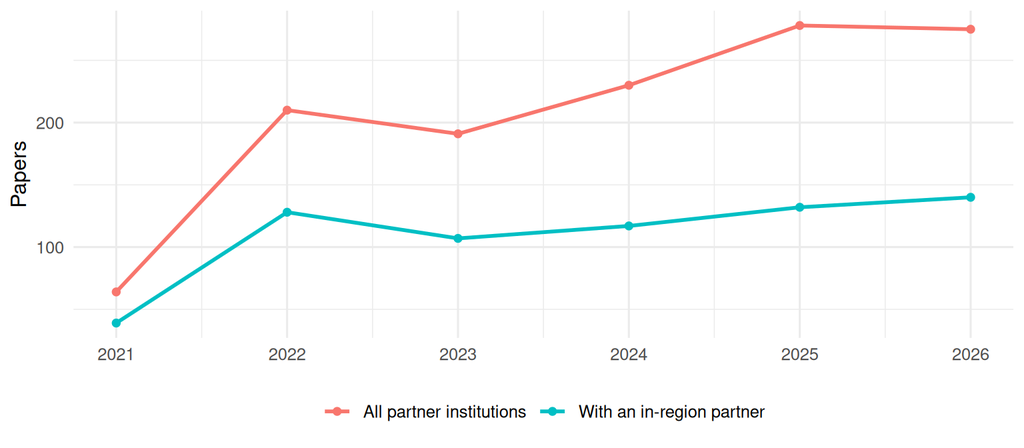

| Partner | Papers in topics |
| --- | --- |
| North Carolina State University | 517 |
| University of Tennessee | 440 |
| Auburn University | 211 |
| Georgia Institute of Technology | 94 |
| HudsonAlpha Institute for Biotechnology | 17 |

## Technology base: patents

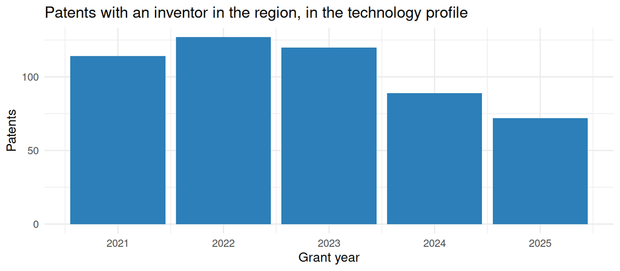

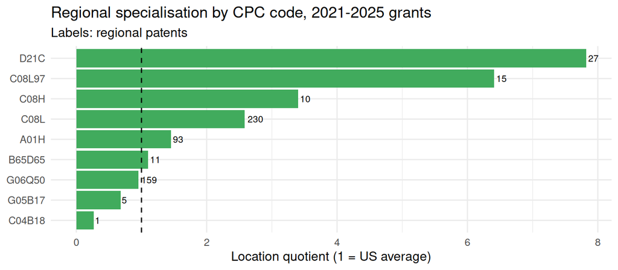

| Assignee | Regional patents in profile |
| --- | --- |
| PIONEER HI-BRED INTERNATIONAL, INC. | 79 |
| Eastman Chemical Company | 61 |
| MDSAVE SHARED SERVICES INC. | 19 |
| UT-BATTELLE, LLC | 19 |
| Bridgestone Americas Tire Operations, LLC | 11 |
| Indigo Ag, Inc. | 10 |
| Synthomer Adhesive Technologies LLC | 10 |
| University of Tennessee Research Foundation | 10 |
| BRIDGESTONE CORPORATION | 8 |
| Southwire Company, LLC | 7 |

Partner-owned patents invented in the region: 222, of which 19 (8.6%) fall in the Engine’s technology profile.

## Competition

With 522 patents in the technology profile (2021-2025 grants), the Engine’s region would rank **21** among US states; its specialisation (LQ) is 1.518.

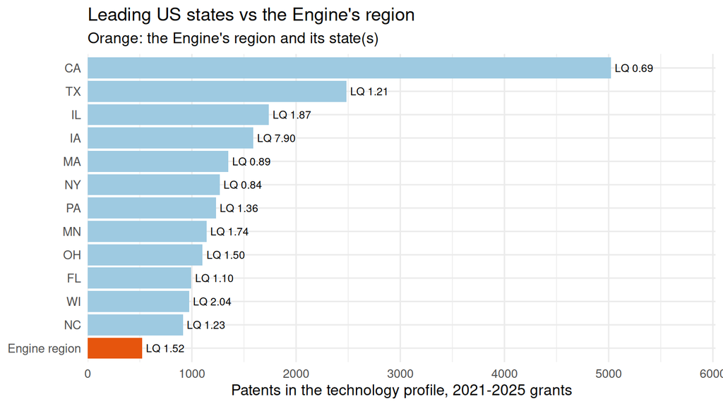

| Country | Share of US patents in profile | Share of world papers in topics |
| --- | --- | --- |
| US | 54.0% | 5.8% |
| JP | 16.4% | 1.5% |
| CN | 5.5% | 16.0% |
| KR | 5.3% | 1.5% |
| DE | 4.6% | 1.8% |
| CA | 3.5% | NA |
| FR | 2.6% | 2.0% |
| GB | 2.1% | 1.9% |
| IN | 2.0% | 17.0% |
| NL | 1.8% | NA |

Patents: inventor countries on US grants in the profile (a patent counts for every country of its inventors). Papers: author countries of OpenAlex works in the Engine’s topics since the window start.

## Data and limitations

- People: PIs and Co-PIs from the NSF Award API; leadership listed on the Engine’s website. Roles come from titles and organisations, revised with OpenAlex evidence.
- Partners: as listed on the Engine’s website, plus organisations of team members. Some Engines publish partner logos without names.
- Region: the Engine’s counties where the list is known (NEO-SMART: 18 Northeast Ohio counties; STELLAR: 11 counties from the NSF abstract), otherwise its states (state-level proxy).
- Technology profile: v1 (switch versions in the header). Partner papers and regional patents depend on it: v1 uses mostly CPC subclasses, the v3.1 core uses CPC main groups, which are narrower, so it counts fewer patents and the LQ of a small region rests on few patents.
- Papers: OpenAlex; partner papers are restricted to the Engine’s OpenAlex topics.
- Patents: USPTO grants 2021-2025; inventor locations from PatentsView; pre-grant publications are not included.